# FIA - NLS Models: Biomass vs. Stand Age, G-Reconciled, Temporally-balanced – Log-Normal

## predict and plot

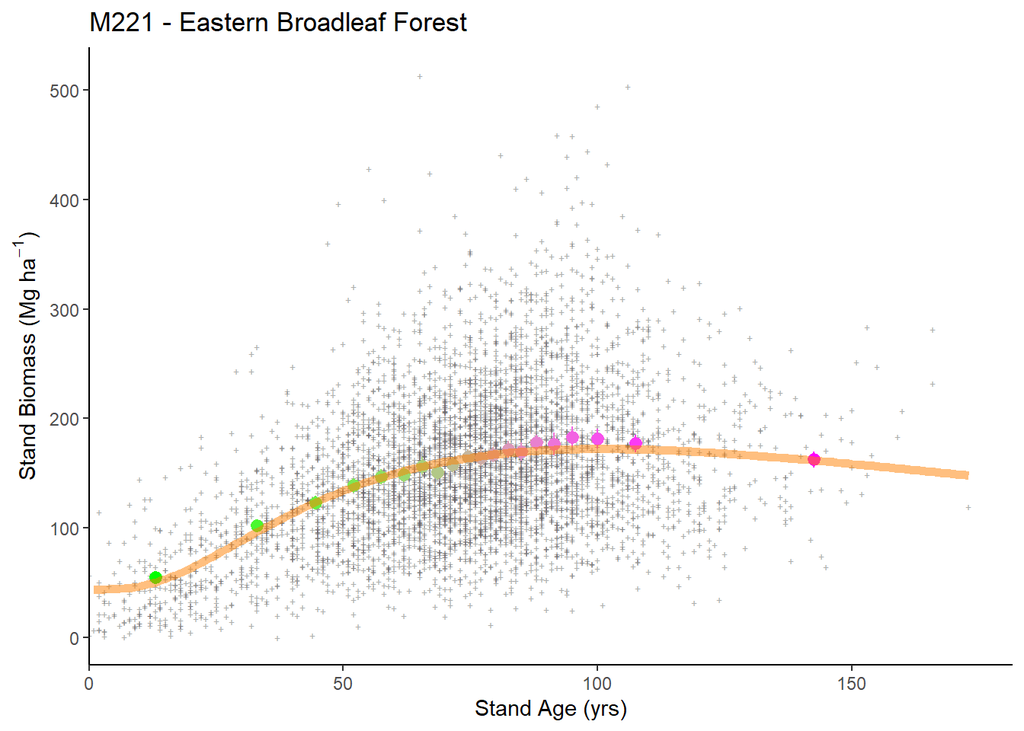

## plotting 2

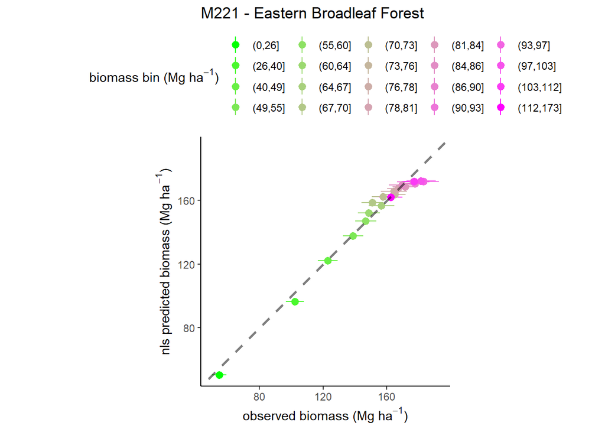

# M223 - Ozark Broadleaf Forest Meadow

## model selection 1

```
## Error in nls(f_ln_3, data = G_M223, start = c(ge = ge.start, phi = phi.start,  :
##   Convergence failure: false convergence (8)
## Analysis of Variance Table
##
## Model 1: B_plt_t2_MgHa ~ (1 + (MEASTIME_t2 - 1990) * ge/100) * (a + b * exp(-((log(STDAGE_t2/c))/d)^2))
## Model 2: B_plt_t2_MgHa ~ (1 + (MEASTIME_t2 - 1990) * ge/100) * (1 + phi * DeltaPDSI) * (a + b * exp(-((log(STDAGE_t2/c))/d)^2))
##   Res.Df Res.Sum Sq Df Sum Sq F value    Pr(>F)
## 1    590     78.320
## 2    589     76.049  1 2.2716  17.594 3.156e-05 ***
## ---
## Signif. codes:  0 '***' 0.001 '**' 0.01 '*' 0.05 '.' 0.1 ' ' 1
##   model      AIC
## 1     1 6067.884
## 2     2 6052.371
## 3     3       NA
```

```
##
## Formula: B_plt_t2_MgHa ~ (1 + (MEASTIME_t2 - 1990) * ge/100) * (1 + phi *
##     DeltaPDSI) * (a + b * exp(-((log(STDAGE_t2/c))/d)^2))
##
## Parameters:
##       Estimate Std. Error t value Pr(>|t|)
## ge  -8.205e-01  2.511e-01  -3.268 0.001148 **
## phi  9.871e-02  2.554e-02   3.864 0.000124 ***
## a    0.000e+00  5.574e+01   0.000 1.000000
## b    3.444e+02  8.677e+02   0.397 0.691602
## c    1.707e+03  1.371e+04   0.125 0.900959
## d    3.290e+00  4.580e+00   0.718 0.472742
## ---
## Signif. codes:  0 '***' 0.001 '**' 0.01 '*' 0.05 '.' 0.1 ' ' 1
##
## Residual standard error: 0.3593 on 589 degrees of freedom
##
## Algorithm "port", convergence message: relative convergence (4)
##   (1 observation deleted due to missingness)
```

### summary

- simple model: fits
- phi model: fits
- phi-alpha model: does not fit

## plot residuals

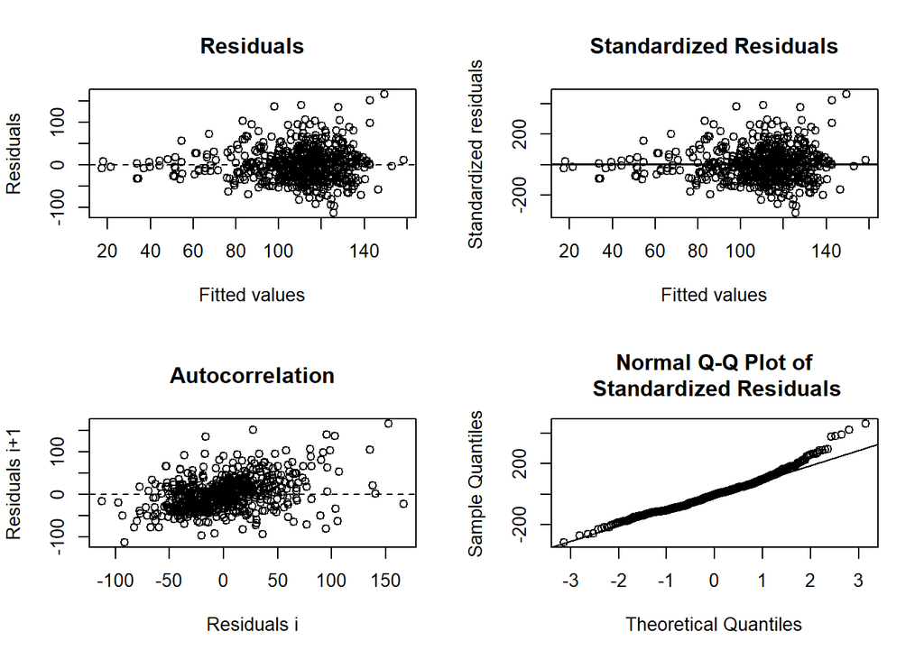

```
##
## ------
##  Shapiro-Wilk normality test
##
## data:  stdres
## W = 0.97629, p-value = 3.143e-08
##
##
## ------
```

```
##
##  Runs Test
##
## data:  as.factor(run)
## Standard Normal = -7.58, p-value = 3.457e-14
## alternative hypothesis: two.sided
```

## predict and plot

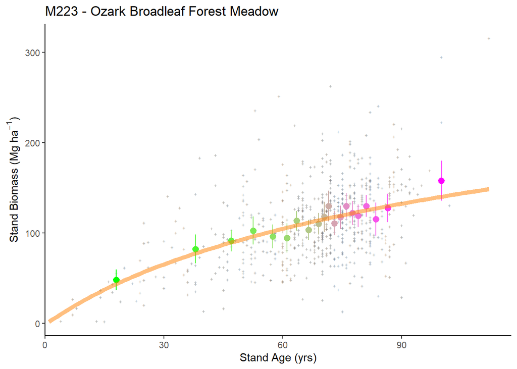

## plotting 2

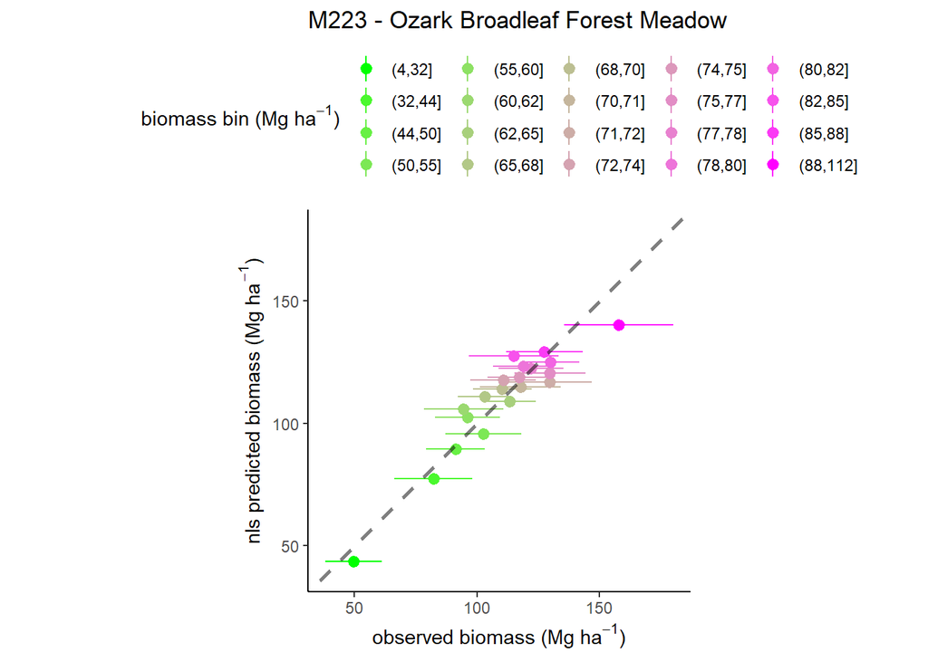

# M231 - Ouachita Mixed Forest

## model selection 1

```
## Error in nls(f_ln_1, data = G_M231, start = c(ge = ge.start, a = a.start,  :
##   Convergence failure: iteration limit reached without convergence (10)
## Error in nls(f_ln_2, data = G_M231, start = c(ge = ge.start, phi = phi.start,  :
##   Convergence failure: iteration limit reached without convergence (10)
##   model      AIC
## 1     1       NA
## 2     2       NA
## 3     3 6845.187
```

```
##
## Formula: B_plt_t2_MgHa ~ (1 + (MEASTIME_t2 - 1990) * ge/100) * (1 + phi *
##     DeltaPDSI) * (1 - alpha * B_L_prop) * (a + b * exp(-((log(STDAGE_t2/c))/d)^2))
##
## Parameters:
##        Estimate Std. Error t value Pr(>|t|)
## ge      0.62483    0.62704   0.996  0.31938
## phi     0.00000    0.02677   0.000  1.00000
## alpha   0.87735    0.10429   8.413 2.48e-16 ***
## a      24.64049    8.77454   2.808  0.00513 **
## b     127.26816   64.35454   1.978  0.04839 *
## c     214.55852  190.09829   1.129  0.25945
## d       1.57266    0.63676   2.470  0.01377 *
## ---
## Signif. codes:  0 '***' 0.001 '**' 0.01 '*' 0.05 '.' 0.1 ' ' 1
##
## Residual standard error: 0.4434 on 660 degrees of freedom
##
## Algorithm "port", convergence message: relative convergence (4)
##   (1 observation deleted due to missingness)
```

### summary

- simple model: does not fit
- phi model: does not fit
- phi-alpha model: fits

## plot residuals

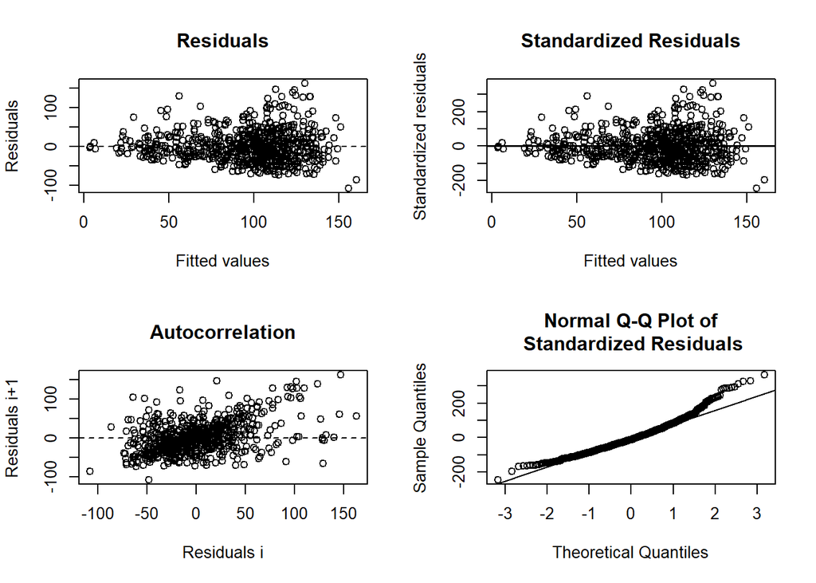

```
##
## ------
##  Shapiro-Wilk normality test
##
## data:  stdres
## W = 0.96164, p-value = 3.425e-12
##
##
## ------
```

```
##
##  Runs Test
##
## data:  as.factor(run)
## Standard Normal = -9.7766, p-value < 2.2e-16
## alternative hypothesis: two.sided
```

## predict and plot

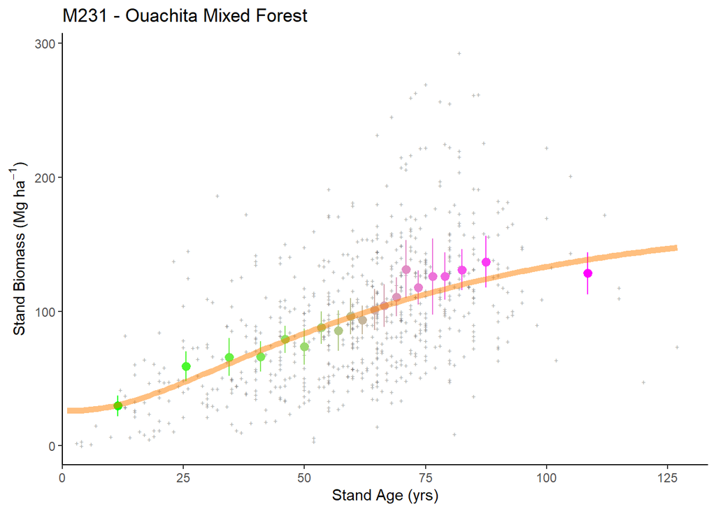

## plotting 2

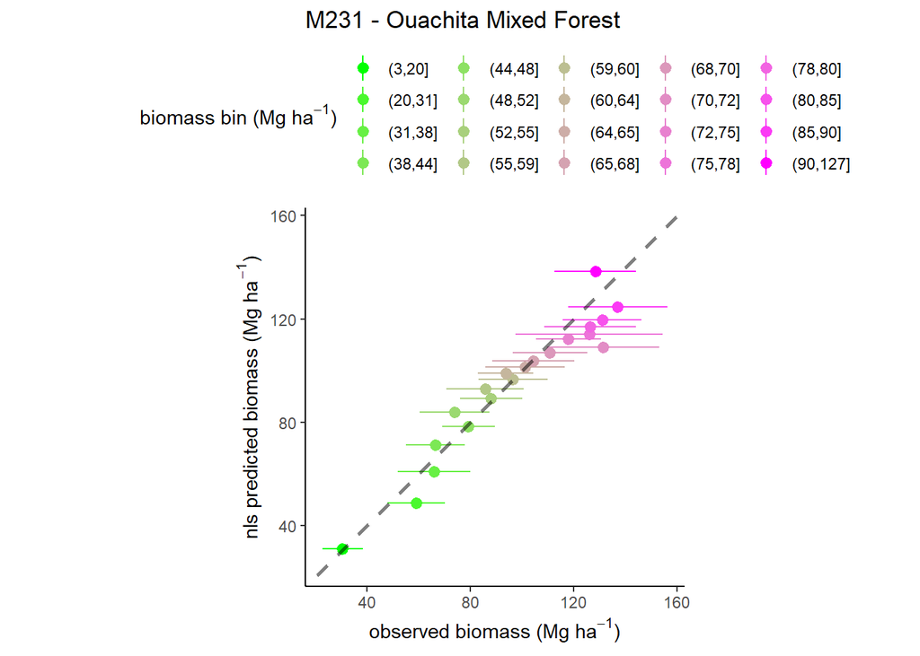

# M242 - Cascade Mixed Forest

## model selection 1

### summary

- simple model: does not fit
- phi model: does not fit
- phi-alpha model: does not fit

## plot residuals

```
## [1] "cannot plot residuals"
```

## predict and plot

```
## [1] "cannot plot data with prediction"
```

## plotting 2

```
## [1] "cannot plot observed vs. predicted"
```

# M261 - Sierran Steppe - Mixed Forest - Coniferous Forest - Alpine Meadow

## model selection 1

```
## Error in if (any(nEQ <- vNms != make.names(vNms))) vNms[nEQ] <- paste0("`",  :
##   missing value where TRUE/FALSE needed
## Error in if (any(nEQ <- vNms != make.names(vNms))) vNms[nEQ] <- paste0("`",  :
##   missing value where TRUE/FALSE needed
## Error in if (any(nEQ <- vNms != make.names(vNms))) vNms[nEQ] <- paste0("`",  :
##   missing value where TRUE/FALSE needed
##   model AIC
## 1     1  NA
## 2     2  NA
## 3     3  NA
```

### summary

- simple model: does not fit
- phi model: does not fit
- phi-alpha model: does not fit

## plot residuals

```
## [1] "cannot plot residuals"
```

## predict and plot

```
## [1] "cannot plot data with prediction"
```

## plotting 2

```
## [1] "cannot plot data with prediction"
```

# M262 - California coastal range - coniferous forest - open woodland - shrub meadow

## Model selection 1

### summary

- simple model: does not fit
- phi model: does not fit
- phi-alpha model: does not fit

## plot residuals

```
## [1] "cannot plot residuals"
```

## predict and plot

```
## [1] "cannot plot data with prediction"
```

## plotting 2

# M313 - Arizona-New Mexico Mountains Semi-Desert - Open Woodland - Coniferous Forest - Alpine Meadow

## model selection 1

```
## Error in if (any(nEQ <- vNms != make.names(vNms))) vNms[nEQ] <- paste0("`",  :
##   missing value where TRUE/FALSE needed
## Error in if (any(nEQ <- vNms != make.names(vNms))) vNms[nEQ] <- paste0("`",  :
##   missing value where TRUE/FALSE needed
## Error in if (any(nEQ <- vNms != make.names(vNms))) vNms[nEQ] <- paste0("`",  :
##   missing value where TRUE/FALSE needed
##   model AIC
## 1     1  NA
## 2     2  NA
## 3     3  NA
```

```
## Error in get(paste("nls_M313.", Mod.Sel1, sep = "")) :
##   object 'nls_M313.' not found
```

### summary

- simple model: does not fit
- phi model: does not fit
- phi-alpha model: does not fit

## plot residuals

```
## [1] "cannot plot residuals"
```

## predict and plot

```
## [1] "cannot plot data with prediction"
```

## plotting 2

# M331 - Southern Rocky Mountain Steppe - Open Woodland - Coniferous Forest - Alpine Meadow

## model selection 1

```
## Error in if (any(nEQ <- vNms != make.names(vNms))) vNms[nEQ] <- paste0("`",  :
##   missing value where TRUE/FALSE needed
## Error in if (any(nEQ <- vNms != make.names(vNms))) vNms[nEQ] <- paste0("`",  :
##   missing value where TRUE/FALSE needed
## Error in if (any(nEQ <- vNms != make.names(vNms))) vNms[nEQ] <- paste0("`",  :
##   missing value where TRUE/FALSE needed
##   model AIC
## 1     1  NA
## 2     2  NA
## 3     3  NA
```

```
## Error in get(paste("nls_M331.", Mod.Sel1, sep = "")) :
##   object 'nls_M331.' not found
```

### summary

- simple model: does not fit
- phi model: does not fit
- phi-alpha model: does not fit

## plot residuals

```
## [1] "cannot plot residuals"
```

## predict and plot

```
## [1] "cannot plot data with prediction"
```

## plotting 2

# M332 - Middle Rocky Mountain Steppe - Coniferous Forest - Alpine Meadow

## model selection 1

### summary

- simple model: does not fit
- phi model: does not fit
- phi-alpha model: does not fit

## plot residuals

```
## [1] "cannot plot residuals"
```

## predict and plot

```
## [1] "cannot plot data with prediction"
```

## plotting 2

# M333 - Northern Rocky Mountain Steppe - Coniferous Forest - Alpine Meadow

## model selection 1

```
## Error in if (any(nEQ <- vNms != make.names(vNms))) vNms[nEQ] <- paste0("`",  :
##   missing value where TRUE/FALSE needed
## Error in if (any(nEQ <- vNms != make.names(vNms))) vNms[nEQ] <- paste0("`",  :
##   missing value where TRUE/FALSE needed
## Error in if (any(nEQ <- vNms != make.names(vNms))) vNms[nEQ] <- paste0("`",  :
##   missing value where TRUE/FALSE needed
##   model AIC
## 1     1  NA
## 2     2  NA
## 3     3  NA
```

```
## Error in get(paste("nls_M333.", Mod.Sel1, sep = "")) :
##   object 'nls_M333.' not found
```

### summary

- simple model: does not fit
- phi model: does not fit
- phi-alpha model: does not fit

## plot residuals

```
## [1] "cannot plot residuals"
```

## predict and plot

```
## [1] "cannot plot data with prediction"
```

## plotting 2

# M334 - Black Hills Coniferous Forest

## model selection 1

```
## Analysis of Variance Table
##
## Model 1: B_plt_t2_MgHa ~ (1 + (MEASTIME_t2 - 1990) * ge/100) * (a + b * exp(-((log(STDAGE_t2/c))/d)^2))
## Model 2: B_plt_t2_MgHa ~ (1 + (MEASTIME_t2 - 1990) * ge/100) * (1 + phi * DeltaPDSI) * (a + b * exp(-((log(STDAGE_t2/c))/d)^2))
## Model 3: B_plt_t2_MgHa ~ (1 + (MEASTIME_t2 - 1990) * ge/100) * (1 + phi * DeltaPDSI) * (1 - alpha * B_L_prop) * (a + b * exp(-((log(STDAGE_t2/c))/d)^2))
##   Res.Df Res.Sum Sq Df  Sum Sq F value    Pr(>F)
## 1    284    110.547
## 2    283    109.679  1  0.8673  2.2378    0.1358
## 3    282     95.119  1 14.5603 43.1670 2.418e-10 ***
## ---
## Signif. codes:  0 '***' 0.001 '**' 0.01 '*' 0.05 '.' 0.1 ' ' 1
##   model      AIC
## 1     1 2887.528
## 2     2 2887.252
## 3     3 2848.089
```

```
##
## Formula: B_plt_t2_MgHa ~ (1 + (MEASTIME_t2 - 1990) * ge/100) * (1 + phi *
##     DeltaPDSI) * (1 - alpha * B_L_prop) * (a + b * exp(-((log(STDAGE_t2/c))/d)^2))
##
## Parameters:
##        Estimate Std. Error t value Pr(>|t|)
## ge     -1.05880    0.48359  -2.189   0.0294 *
## phi     0.01114    0.03486   0.319   0.7496
## alpha   0.79284    0.10346   7.663 2.93e-13 ***
## a       8.62796   69.79262   0.124   0.9017
## b     102.00787  108.27222   0.942   0.3469
## c     318.26805  712.08749   0.447   0.6553
## d       2.45476    3.05659   0.803   0.4226
## ---
## Signif. codes:  0 '***' 0.001 '**' 0.01 '*' 0.05 '.' 0.1 ' ' 1
##
## Residual standard error: 0.5808 on 282 degrees of freedom
##
## Algorithm "port", convergence message: relative convergence (4)
##   (1 observation deleted due to missingness)
```

### summary

- simple model: fits
- phi model: fits
- phi-alpha model: fits

## plot residuals

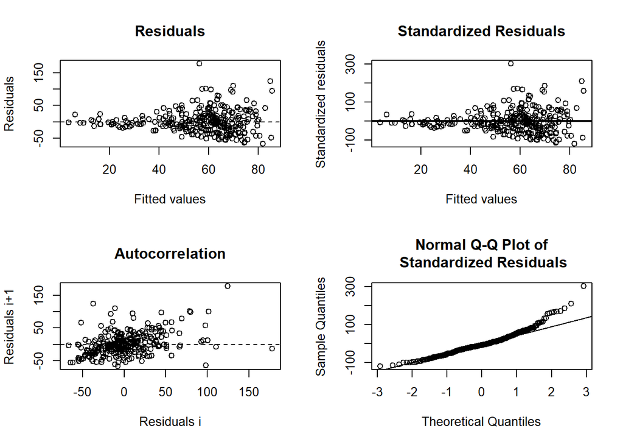

```
##
## ------
##  Shapiro-Wilk normality test
##
## data:  stdres
## W = 0.94271, p-value = 3.637e-09
##
##
## ------
```

```
##
##  Runs Test
##
## data:  as.factor(run)
## Standard Normal = -4.8575, p-value = 1.189e-06
## alternative hypothesis: two.sided
```

## predict and plot

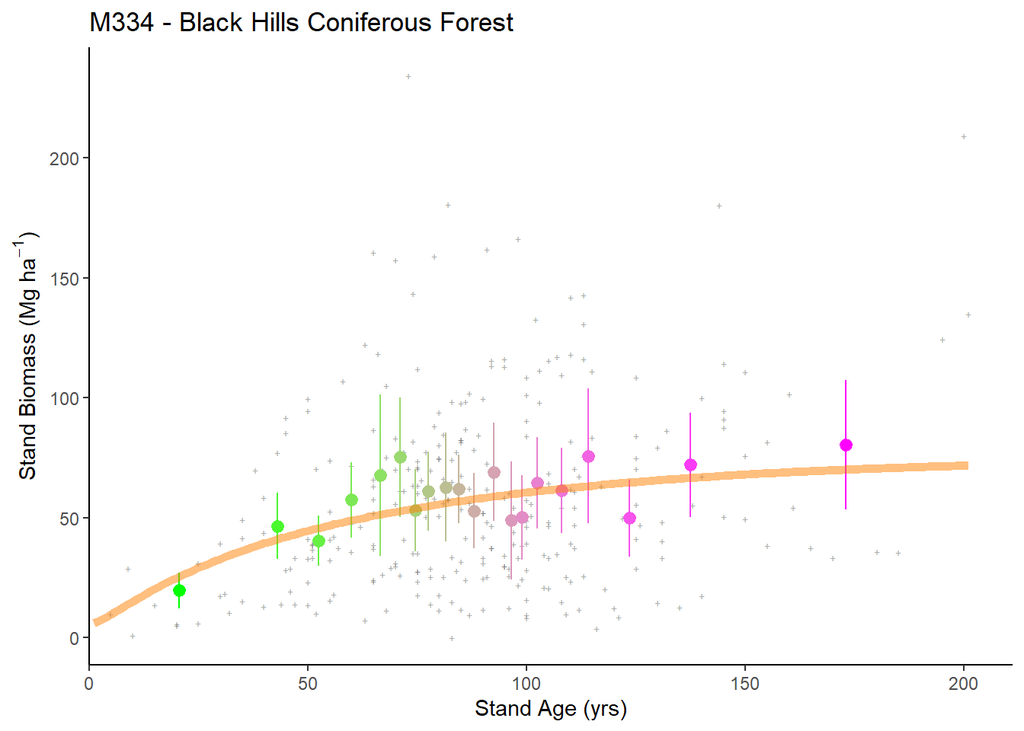

## plotting 2

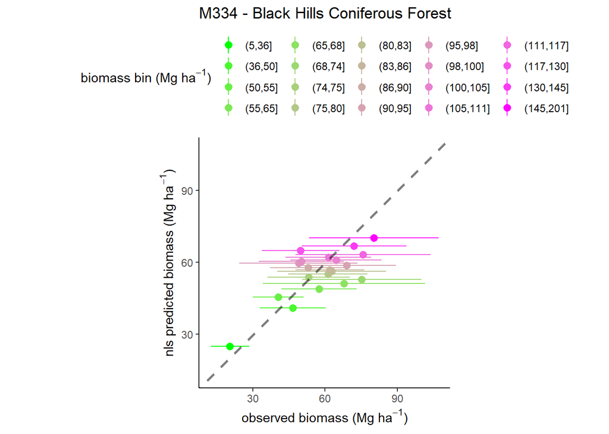

# M341 - Nevada-Utah Mountains Semi-Desert - Coniferous Forest - Alpine Meadow

## model selection 1

```
## Error in if (any(nEQ <- vNms != make.names(vNms))) vNms[nEQ] <- paste0("`",  :
##   missing value where TRUE/FALSE needed
## Error in if (any(nEQ <- vNms != make.names(vNms))) vNms[nEQ] <- paste0("`",  :
##   missing value where TRUE/FALSE needed
## Error in if (any(nEQ <- vNms != make.names(vNms))) vNms[nEQ] <- paste0("`",  :
##   missing value where TRUE/FALSE needed
##   model AIC
## 1     1  NA
## 2     2  NA
## 3     3  NA
```

```
## Error in get(paste("nls_M341.", Mod.Sel1, sep = "")) :
##   object 'nls_M341.' not found
```

### summary

- simple model: does not fit
- phi model: does not fit
- phi-alpha model: does not fit

## plot residuals

```
## [1] "cannot plot residuals"
```

## predict and plot

```
## [1] "cannot plot data with prediction"
```

## plotting 2

# Fitted parameters

## Best / selected models by ecoprovince

| Code | Ecoregion | Sel.Mod |
| --- | --- | --- |
| 211 | Northeastern Mixed Forest | 3 |
| 212 | Laurentian Mixed Forest | 3 |
| 221 | Eastern Broadleaf Forest | 3 |
| 222 | Midwest Broadleaf Forest | 3 |
| 223 | Central Interior Broadleaf Forest | 3 |
| 231 | Southeastern Mixed Forest | 3 |
| 232 | Outer Coastal Plain Mixed Forest | 3 |
| 234 | Lower Mississippi Riverine Forest | 3 |
| 242 | Pacific Lowland Mixed Forest | NA |
| 251 | Prairie Parkland (Temperate) | 3 |
| 255 | Prairie Parkland (Subtropical) | 3 |
| 261 | California Coastal Chaparral Forest and Shrub | NA |
| 262 | California Dry Steppe | NA |
| 263 | California Coastal Steppe - Mixed Forest and Redwood Forest | NA |
| 313 | Colorado Plateau Semi-Desert | NA |
| 315 | Southwest Plateau and Plains Dry Steppe and Shrub | NA |
| 321 | Chihuahuan Semi-Desert | NA |
| 322 | American Semidesert and Desert | NA |
| 331 | Great Plains/Palouse Dry Steppe | NA |
| 332 | Great Plains Steppe | NA |
| 341 | Intermountain Semi-Desert and Desert | NA |
| 342 | Intermountain Semi-Desert | NA |
| 411 | Everglades | NA |
| M211 | Adirondack-New England Mixed forest - Coniferous Forest - Alpine Meadow | 3 |
| M221 | Central Appalachian Broadleaf Forest - Coniferous Forest - Meadow | 3 |
| M223 | Ozark Broadleaf Forest Meadow | 2 |
| M231 | Ouachita Mixed Forest | 3 |
| M242 | Cascade Mixed Forest | NA |
| M261 | Sierran Steppe - Mixed Forest - Coniferous Forest - Alpine Meadow | NA |
| M262 | California Coastal Range Coniferous Forest - Open Woodland - Shrub - Meadow | NA |
| M313 | Arizona-New Mexico Mountains Semi-Desert - Open Woodland - Coniferous Forest - Alpine Meadow | NA |
| M331 | Southern Rocky Mountain Steppe - Open Woodland - Coniferous Forest - Alpine Meadow | NA |
| M332 | Middle Rocky Mountain Steppe - Coniferous Forest - Alpine Meadow | NA |
| M333 | Northern Rocky Mountain Steppe - Coniferous Forest - Alpine Meadow | NA |
| M334 | Black Hills Coniferous Forest | 3 |
| M341 | Nevada-Utah Mountains Semi-Desert - Coniferous Forest - Alpine Meadow | NA |

## table by ecoprovince

| Code | Ecoregion | region | n.obs | n.plots | ge | ge.2.5 | ge.97.5 | phi | phi.2.5 | phi.97.5 | alpha | alpha.2.5 | alpha.97.5 | a | a.2.5 | a.97.5 | b | b.2.5 | b.97.5 | c | c.2.5 | c.97.5 | d | d.2.5 | d.97.5 |
| --- | --- | --- | --- | --- | --- | --- | --- | --- | --- | --- | --- | --- | --- | --- | --- | --- | --- | --- | --- | --- | --- | --- | --- | --- | --- |
| 211 | Northeastern Mixed Forest | east | 4776 | 2388 | 0.3762549 | -0.0237483 | 0.7762580 | 0.0123019 | -0.0014401 | 0.0260440 | 0.8492187 | 0.7829753 | 0.9154622 | 42.381443 | 38.097686 | 46.66520 | 112.47523 | 101.6662310 | 123.28422 | 111.05168 | 102.66332 | 119.44005 | 0.8828713 | 0.7984388 | 0.9673038 |
| 212 | Laurentian Mixed Forest | east | 11688 | 5844 | 0.7063269 | 0.4298166 | 0.9828373 | 0.0010290 | -0.0076886 | 0.0097467 | 0.7602315 | 0.7144606 | 0.8060024 | 23.178591 | 21.473010 | 24.88417 | 75.96730 | 71.0646739 | 80.86993 | 110.47330 | 103.02134 | 117.92525 | 1.1975819 | 1.1224929 | 1.2726709 |
| 221 | Eastern Broadleaf Forest | east | 5350 | 2675 | 0.2771604 | 0.0011157 | 0.5532050 | 0.0000000 | -0.0106497 | 0.0106497 | 0.8254081 | 0.7656376 | 0.8851786 | 31.123190 | 25.254011 | 36.99237 | 162.21108 | 144.5903674 | 179.83179 | 140.36648 | 117.14688 | 163.58607 | 1.3552080 | 1.1936914 | 1.5167245 |
| 222 | Midwest Broadleaf Forest | east | 3248 | 1624 | 0.0584072 | -0.4134462 | 0.5302607 | 0.0374955 | 0.0141115 | 0.0608794 | 0.8897826 | 0.7970226 | 0.9825426 | 25.020114 | 20.752459 | 29.28777 | 115.79193 | 102.5298670 | 129.05400 | 106.46528 | 94.62989 | 118.30066 | 1.0471547 | 0.9267189 | 1.1675905 |
| 223 | Central Interior Broadleaf Forest | east | 6046 | 3023 | 0.2343353 | -0.0169256 | 0.4855963 | 0.0000000 | -0.0123717 | 0.0123717 | 0.7811738 | 0.7194163 | 0.8429314 | 31.881833 | 25.822522 | 37.94114 | 103.36704 | 93.6404915 | 113.09359 | 111.96607 | 98.27823 | 125.65392 | 1.2925366 | 1.1317707 | 1.4533025 |
| 231 | Southeastern Mixed Forest | east | 7532 | 3766 | 1.6376444 | 1.3099512 | 1.9653375 | 0.0000000 | -0.0108229 | 0.0108229 | 0.7284631 | 0.6891593 | 0.7677669 | 24.434475 | 22.443903 | 26.42505 | 109.49970 | 99.9794285 | 119.01998 | 108.79323 | 93.32500 | 124.26145 | 1.4810730 | 1.3564945 | 1.6056515 |
| 232 | Outer Coastal Plain Mixed Forest | east | 7568 | 3784 | 1.1191284 | 0.7688360 | 1.4694209 | 0.0245717 | 0.0109564 | 0.0381871 | 0.7035387 | 0.6578326 | 0.7492448 | 24.728892 | 22.220093 | 27.23769 | 117.88718 | 105.2863997 | 130.48796 | 122.43839 | 99.40528 | 145.47150 | 1.5543077 | 1.3957039 | 1.7129115 |
| 234 | Lower Mississippi Riverine Forest | east | 784 | 392 | 0.2759513 | -0.7104905 | 1.2623932 | 0.0132659 | -0.0313108 | 0.0578426 | 0.8170799 | 0.6843317 | 0.9498280 | 0.000000 | -98.435581 | 98.43558 | 683.47665 | -4920.6312175 | 6287.58452 | 5000.00000 | -113646.61614 | 123646.61614 | 3.5313003 | -6.9466353 | 14.0092359 |
| 242 | Pacific Lowland Mixed Forest | pacific | 0 | 0 | NA | NA | NA | NA | NA | NA | NA | NA | NA | NA | NA | NA | NA | NA | NA | NA | NA | NA | NA | NA | NA |
| 251 | Prairie Parkland (Temperate) | east | 1248 | 624 | 0.3415225 | -0.3810140 | 1.0640590 | 0.0000000 | -0.0283244 | 0.0283244 | 0.6999305 | 0.5435036 | 0.8563574 | 23.463974 | 8.547027 | 38.38092 | 98.81354 | 75.6521808 | 121.97490 | 110.33191 | 84.85259 | 135.81122 | 1.2420086 | 0.9023014 | 1.5817157 |
| 255 | Prairie Parkland (Subtropical) | pacific | 410 | 205 | 0.0401577 | -0.8824730 | 0.9627884 | 0.0000000 | -0.0713182 | 0.0713182 | 0.8016457 | 0.5605194 | 1.0427721 | 19.870839 | 8.338153 | 31.40352 | 74.30714 | 54.1924898 | 94.42179 | 57.29565 | 45.05311 | 69.53819 | 1.0741066 | 0.7399378 | 1.4082754 |
| 261 | California Coastal Chaparral Forest and Shrub | pacific | 0 | 0 | NA | NA | NA | NA | NA | NA | NA | NA | NA | NA | NA | NA | NA | NA | NA | NA | NA | NA | NA | NA | NA |
| 262 | California Dry Steppe | pacific | 0 | 0 | NA | NA | NA | NA | NA | NA | NA | NA | NA | NA | NA | NA | NA | NA | NA | NA | NA | NA | NA | NA | NA |
| 263 | California Coastal Steppe - Mixed Forest and Redwood Forest | pacific | 0 | 0 | NA | NA | NA | NA | NA | NA | NA | NA | NA | NA | NA | NA | NA | NA | NA | NA | NA | NA | NA | NA | NA |
| 313 | Colorado Plateau Semi-Desert | interior west | 0 | 0 | NA | NA | NA | NA | NA | NA | NA | NA | NA | NA | NA | NA | NA | NA | NA | NA | NA | NA | NA | NA | NA |
| 315 | Southwest Plateau and Plains Dry Steppe and Shrub | interior west | 0 | 0 | NA | NA | NA | NA | NA | NA | NA | NA | NA | NA | NA | NA | NA | NA | NA | NA | NA | NA | NA | NA | NA |
| 321 | Chihuahuan Semi-Desert | interior west | 0 | 0 | NA | NA | NA | NA | NA | NA | NA | NA | NA | NA | NA | NA | NA | NA | NA | NA | NA | NA | NA | NA | NA |
| 322 | American Semidesert and Desert | interior west | 0 | 0 | NA | NA | NA | NA | NA | NA | NA | NA | NA | NA | NA | NA | NA | NA | NA | NA | NA | NA | NA | NA | NA |
| 331 | Great Plains/Palouse Dry Steppe | interior west | 104 | 52 | NA | NA | NA | NA | NA | NA | NA | NA | NA | NA | NA | NA | NA | NA | NA | NA | NA | NA | NA | NA | NA |
| 332 | Great Plains Steppe | interior west | 132 | 66 | 5.0000000 | -11.8593627 | 21.8593627 | 0.0000000 | -0.1205361 | 0.1205361 | 1.0443143 | 0.5931236 | 1.4955049 | 18.609682 | -15.629748 | 52.84911 | 31.48341 | -28.4082178 | 91.37503 | 113.07383 | -91.35503 | 317.50269 | 0.9659490 | -0.7498141 | 2.6817121 |
| 341 | Intermountain Semi-Desert and Desert | interior west | 0 | 0 | NA | NA | NA | NA | NA | NA | NA | NA | NA | NA | NA | NA | NA | NA | NA | NA | NA | NA | NA | NA | NA |
| 342 | Intermountain Semi-Desert | interior west | 2 | 1 | NA | NA | NA | NA | NA | NA | NA | NA | NA | NA | NA | NA | NA | NA | NA | NA | NA | NA | NA | NA | NA |
| 411 | Everglades | east | 64 | 32 | NA | NA | NA | NA | NA | NA | NA | NA | NA | NA | NA | NA | NA | NA | NA | NA | NA | NA | NA | NA | NA |
| M211 | Adirondack-New England Mixed forest - Coniferous Forest - Alpine Meadow | east | 5068 | 2534 | 0.2469244 | -0.0439702 | 0.5378190 | 0.0325877 | 0.0200225 | 0.0451528 | 0.8227291 | 0.7710455 | 0.8744126 | 22.394682 | 16.283617 | 28.50575 | 148.30001 | 129.6388526 | 166.96116 | 171.38878 | 136.91249 | 205.86507 | 1.4859207 | 1.2891944 | 1.6826470 |
| M221 | Central Appalachian Broadleaf Forest - Coniferous Forest - Meadow | east | 5104 | 2552 | 0.8793389 | 0.6026529 | 1.1560249 | 0.0000000 | -0.0107768 | 0.0107768 | 0.8337075 | 0.7574194 | 0.9099955 | 39.345493 | 33.977032 | 44.71395 | 114.35351 | 105.7855786 | 122.92144 | 100.91398 | 93.69815 | 108.12982 | 1.1797681 | 1.0668636 | 1.2926727 |
| M223 | Ozark Broadleaf Forest Meadow | east | 596 | 298 | -0.8205180 | -1.3137013 | -0.3273347 | 0.0987059 | 0.0485365 | 0.1488753 | NA | NA | NA | 0.000000 | -109.481359 | 109.48136 | 344.38981 | -1359.8701682 | 2048.64978 | 1706.50809 | -25213.10035 | 28626.11654 | 3.2904412 | -5.7040462 | 12.2849286 |
| M231 | Ouachita Mixed Forest | east | 668 | 334 | 0.6248349 | -0.6063909 | 1.8560607 | 0.0000000 | -0.0525596 | 0.0525596 | 0.8773519 | 0.6725712 | 1.0821325 | 24.640490 | 7.411109 | 41.86987 | 127.26816 | 0.9038568 | 253.63246 | 214.55852 | -158.71180 | 587.82885 | 1.5726578 | 0.3223444 | 2.8229712 |
| M242 | Cascade Mixed Forest | pacific | 6 | 3 | NA | NA | NA | NA | NA | NA | NA | NA | NA | NA | NA | NA | NA | NA | NA | NA | NA | NA | NA | NA | NA |
| M261 | Sierran Steppe - Mixed Forest - Coniferous Forest - Alpine Meadow | pacific | 0 | 0 | NA | NA | NA | NA | NA | NA | NA | NA | NA | NA | NA | NA | NA | NA | NA | NA | NA | NA | NA | NA | NA |
| M262 | California Coastal Range Coniferous Forest - Open Woodland - Shrub - Meadow | interior west | 0 | 0 | NA | NA | NA | NA | NA | NA | NA | NA | NA | NA | NA | NA | NA | NA | NA | NA | NA | NA | NA | NA | NA |
| M313 | Arizona-New Mexico Mountains Semi-Desert - Open Woodland - Coniferous Forest - Alpine Meadow | interior west | 0 | 0 | NA | NA | NA | NA | NA | NA | NA | NA | NA | NA | NA | NA | NA | NA | NA | NA | NA | NA | NA | NA | NA |
| M331 | Southern Rocky Mountain Steppe - Open Woodland - Coniferous Forest - Alpine Meadow | interior west | 0 | 0 | NA | NA | NA | NA | NA | NA | NA | NA | NA | NA | NA | NA | NA | NA | NA | NA | NA | NA | NA | NA | NA |
| M332 | Middle Rocky Mountain Steppe - Coniferous Forest - Alpine Meadow | interior west | 2 | 1 | NA | NA | NA | NA | NA | NA | NA | NA | NA | NA | NA | NA | NA | NA | NA | NA | NA | NA | NA | NA | NA |
| M333 | Northern Rocky Mountain Steppe - Coniferous Forest - Alpine Meadow | interior west | 0 | 0 | NA | NA | NA | NA | NA | NA | NA | NA | NA | NA | NA | NA | NA | NA | NA | NA | NA | NA | NA | NA | NA |
| M334 | Black Hills Coniferous Forest | interior west | 290 | 145 | -1.0588047 | -2.0107060 | -0.1069033 | 0.0111378 | -0.0574876 | 0.0797632 | 0.7928359 | 0.5891881 | 0.9964836 | 8.627963 | -128.752661 | 146.00859 | 102.00787 | -111.1164573 | 315.13220 | 318.26805 | -1083.41343 | 1719.94953 | 2.4547555 | -3.5618771 | 8.4713881 |
| M341 | Nevada-Utah Mountains Semi-Desert - Coniferous Forest - Alpine Meadow | interior west | 0 | 0 | NA | NA | NA | NA | NA | NA | NA | NA | NA | NA | NA | NA | NA | NA | NA | NA | NA | NA | NA | NA | NA |

## plot ge

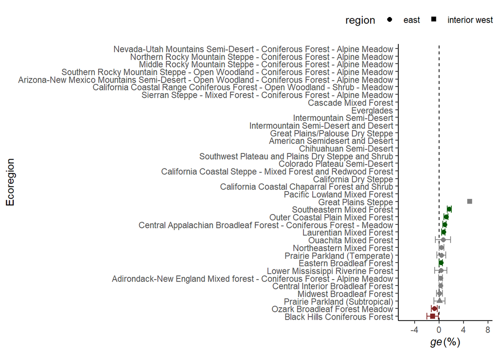

### map

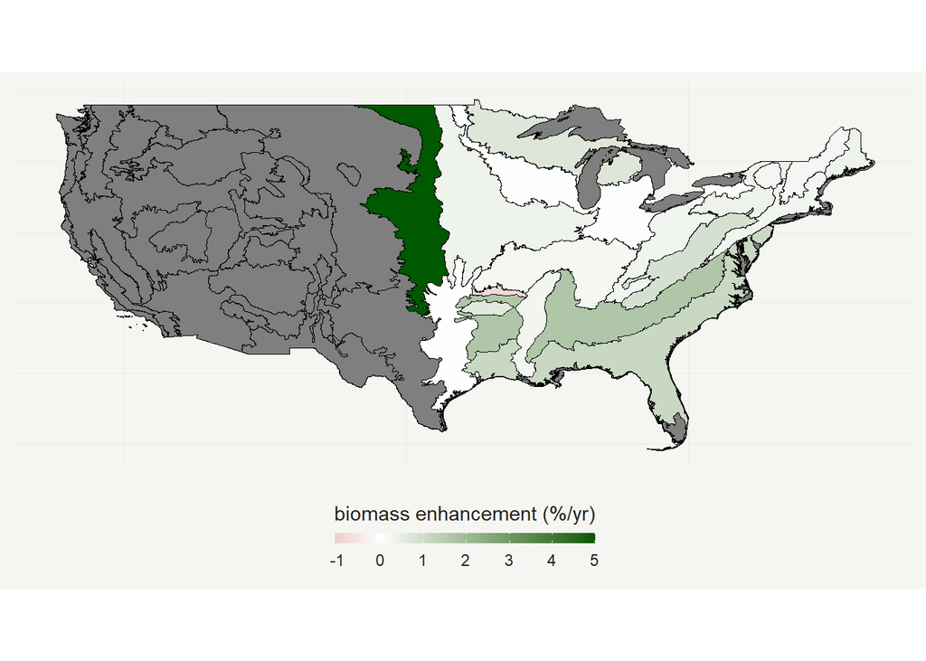

### map #2

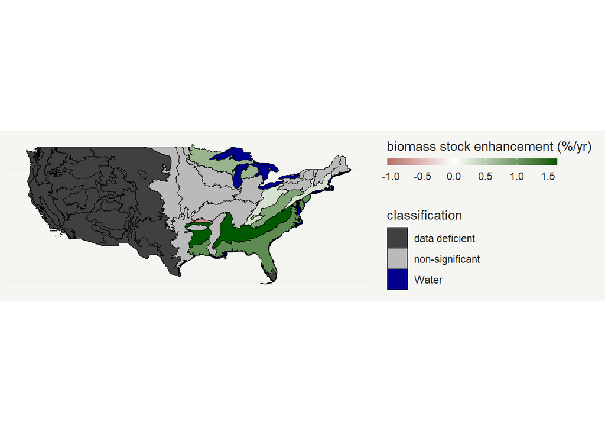

## plot phi (effect of DeltaPDSI)

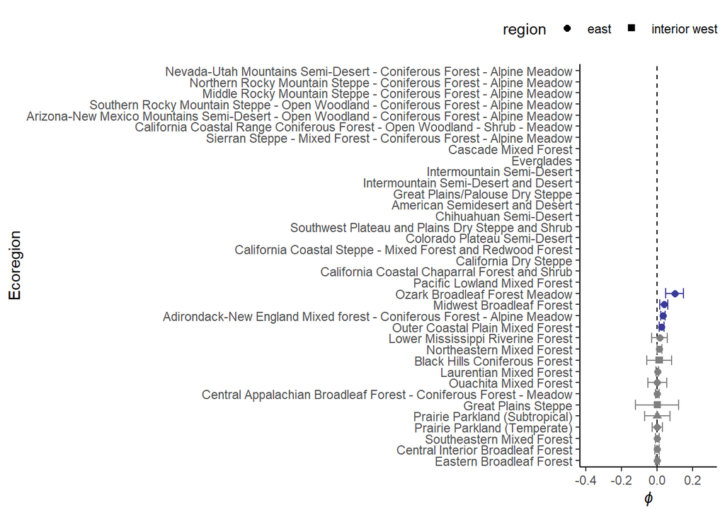

## plot alpha (biomass compensation effect)

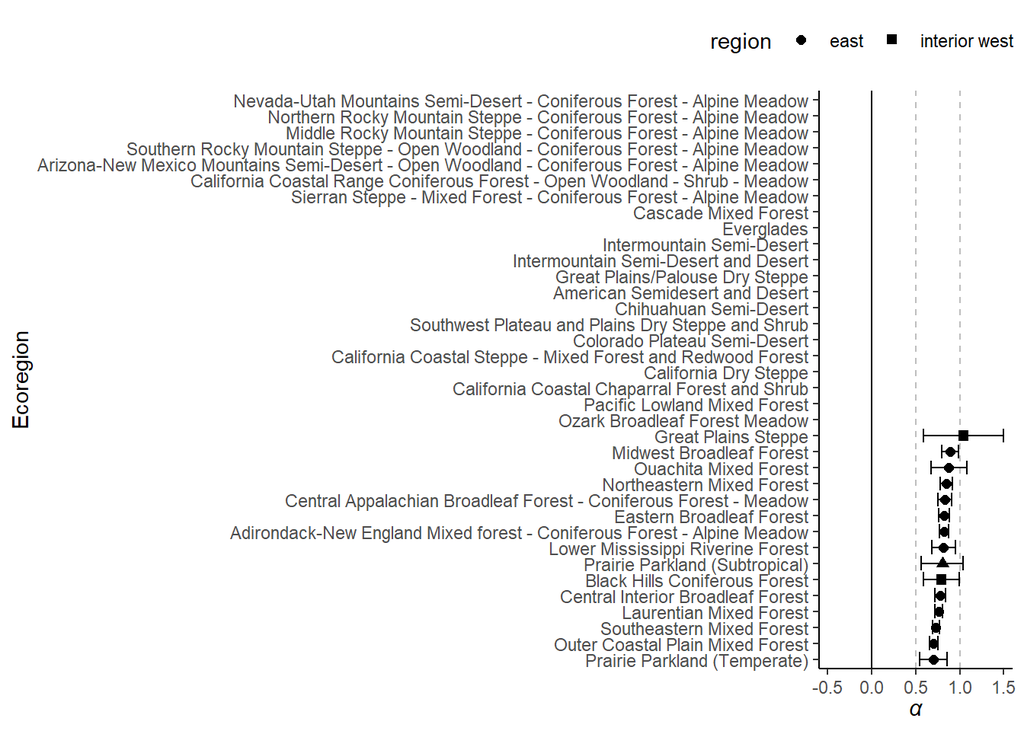

## plot a coefficient

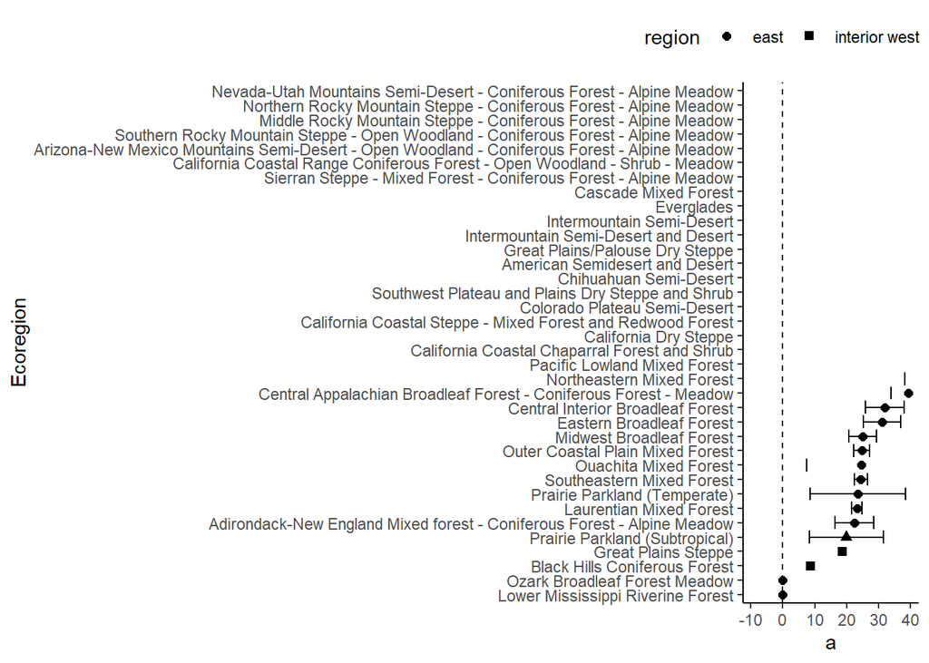

## plot b coefficient

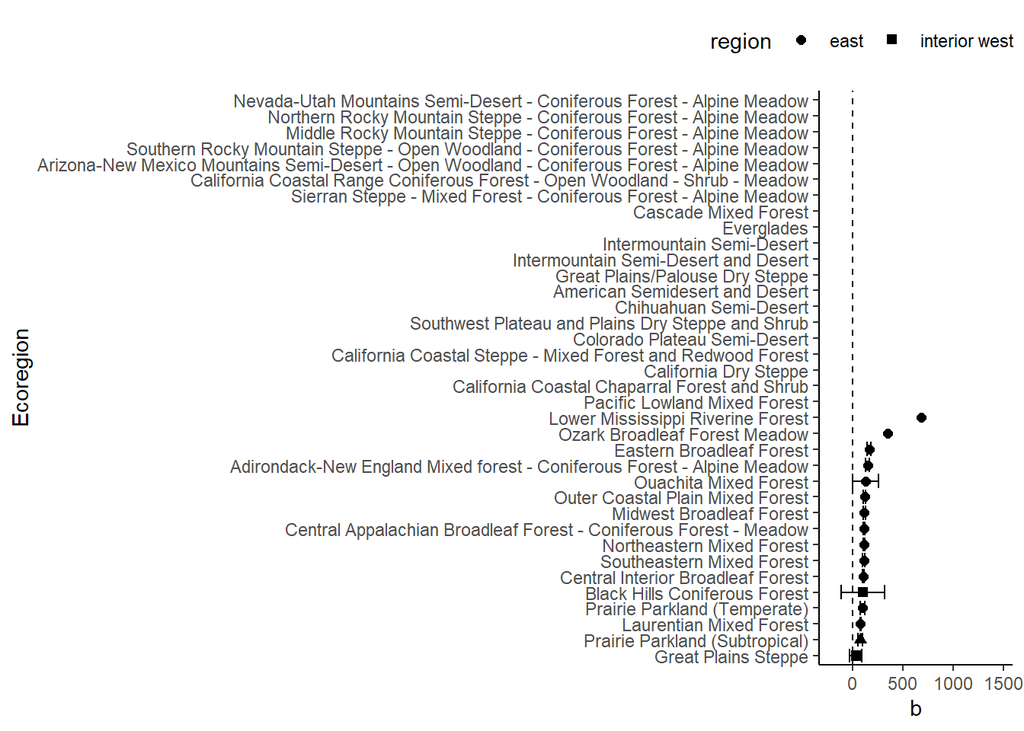

## plot c coefficient

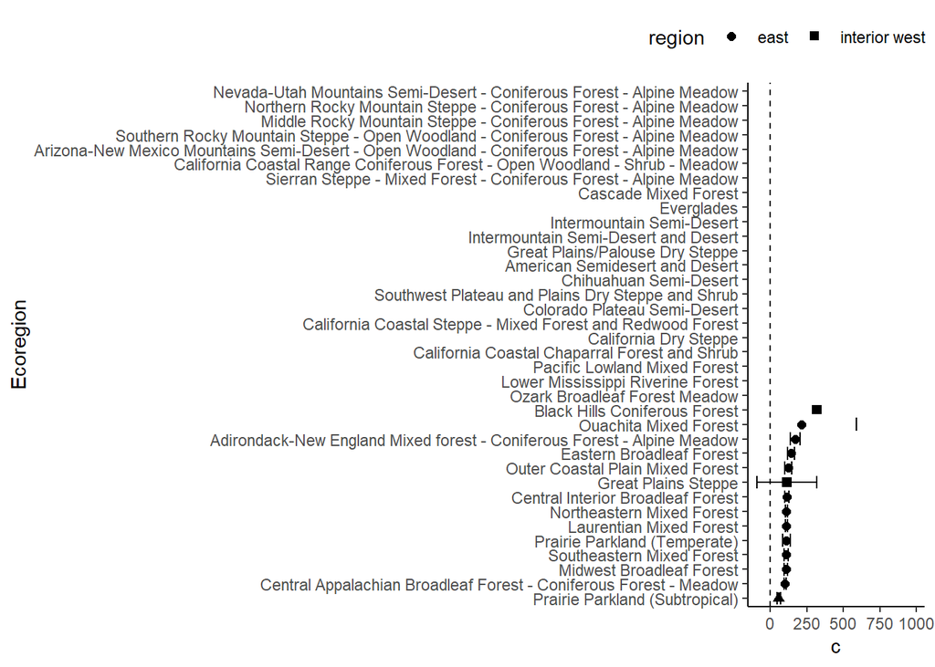

## plot d coefficient

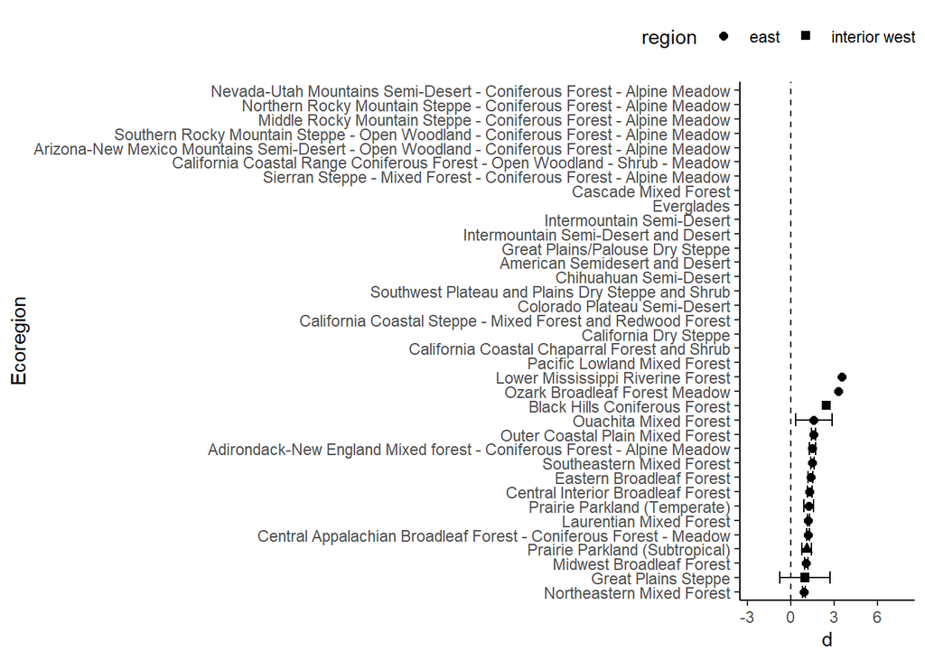

# Caclulations - weighted averages

## ge (stand biomass enhancement factor in % 2000-2021)

```
##          region weighted.ge
## 1     entire US  0.66944677
## 2       pacific  0.03957846
## 3          east  0.67386400
## 4 interior west  0.66593706
```

## phi (effect of DeltaPDSI)

```
##          region weighted.phi
## 1     entire US  0.010152895
## 2       pacific  0.000000000
## 3          east  0.010259602
## 4 interior west  0.006094276
```

## alpha (biomass compensation effect)

```
##          region weighted.alpha
## 1     entire US      0.7745279
## 2       pacific      0.7900835
## 3          east      0.7751348
## 4 interior west      0.6939092
```

# Calculations - weighted averages subsetted to 15 ecoprovinces

- 211, 212, 221, 223, 231, 232, 234, 251, M211, M221, M223, M231, M242, M261, M332

## ge

```
##          region weighted.ge
## 1     entire US   0.7099534
## 2       pacific   0.0000000
## 3          east   0.7100540
## 4 interior west   0.0000000
```

## phi

```
##          region weighted.phi
## 1     entire US  0.008702307
## 2       pacific  0.000000000
## 3          east  0.008703541
## 4 interior west  0.000000000
```

## alpha

```
##          region weighted.alpha
## 1     entire US      0.7693057
## 2       pacific      0.0000000
## 3          east      0.7694148
## 4 interior west      0.0000000
```